# Lab 01 - Depth measures

```r
depthPersp(df_bivariate_exp,depth_params = list(method='Mahalanobis'),plot_method = 'rgl')
```

[interactive chart not shown]

Please note that anything that comes out of `depthContour` or `depthPersp` is *NOT* a density: we are not doing density estimation here, we are performing data exploration by means of a nonparametric procedure. Let us plot the probability density function (NOT the depth function) of the bivariate exponential distribution we drew a sample from:

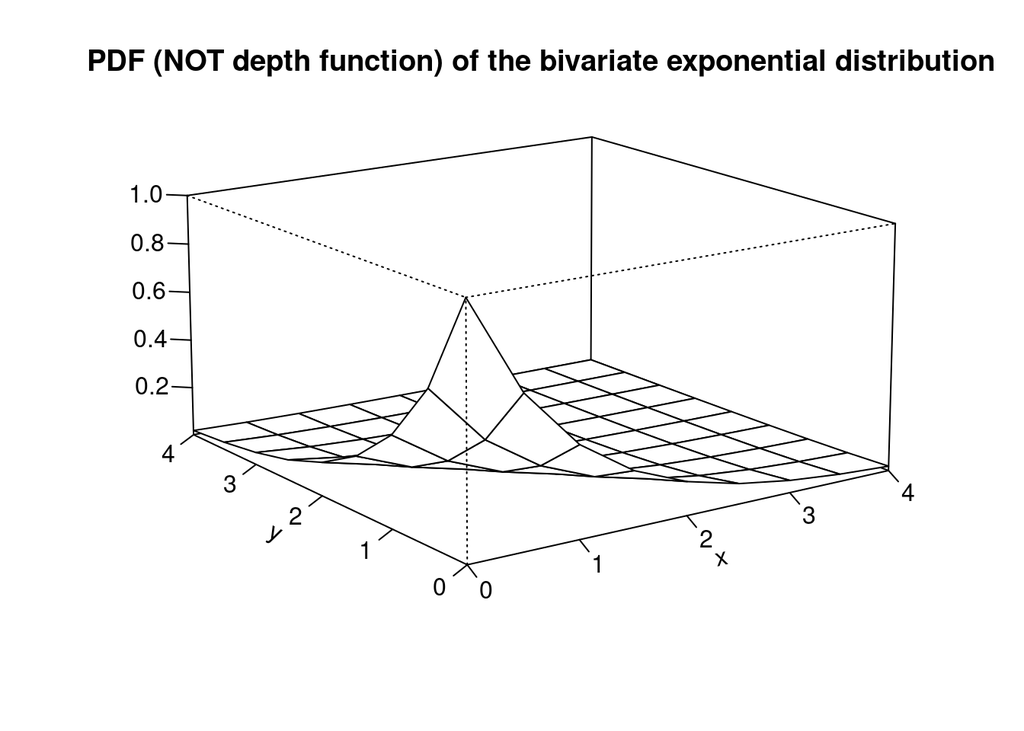

```r
#install.packages("devtools")
#devtools::install_local("~/Downloads/MDBED_1.0.0.tar.gz")
library(MDBED)
PDF_3dPlot(rho = 0, Betax = 1, Betay = 1, title="PDF (NOT depth function) of the bivariate exponential distribution", zlabel="")
```

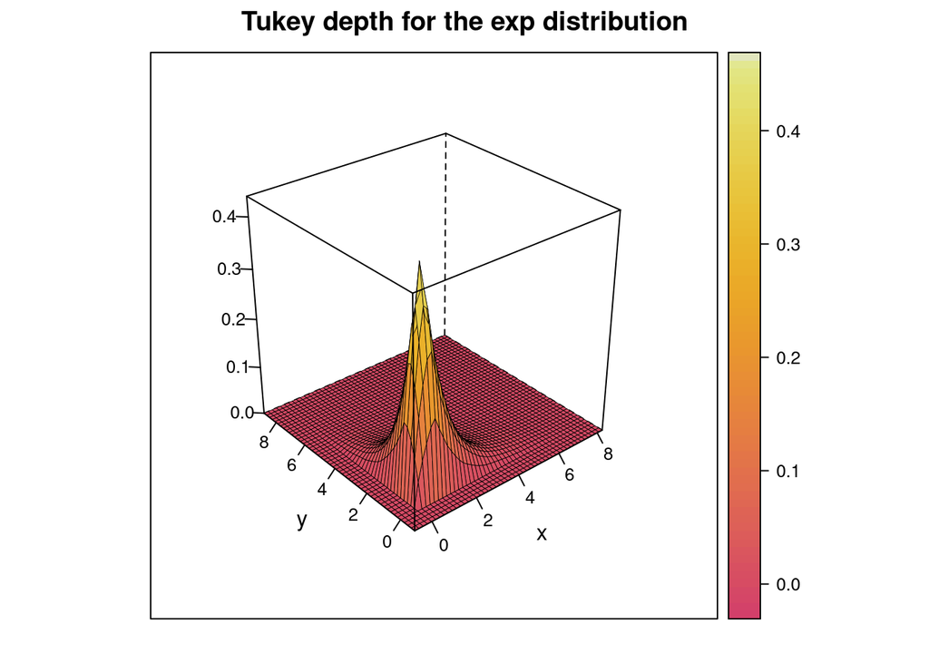

```r
depthPersp(cbind(rexp(1e4), rexp(1e4)),depth_params = list(method='Tukey'), plot_title="Tukey depth for the exp distribution")
```

We notice that the tukey depth concentrates around the median, where as the exponential bivariate function increases as x,y go to 0.

### Exercise

Try out the routines seen so far on something even more exotic:

```r
set.seed(1992)
df_bivariate_cauchy = cbind(rcauchy(n,location=0,scale=.001), rcauchy(n,location = 0,scale=.001))
head(df_bivariate_cauchy)
```

```
##               [,1]         [,2]
## [1,] -0.0024184800 0.0008798105
## [2,] -0.0006282804 0.0009932694
## [3,] -0.0006975300 0.0010347342
## [4,] -0.0038080204 0.0141419885
## [5,]  0.0061098712 0.0014929490
## [6,] -0.0012696290 0.0008865863
```

The Cauchy distribution is a distribution that has neither the first moment (the mean) nor the second moment (the variance). This means that the CLT does not apply.

- Can we still perform non-parametric data exploration with depth measures?
- Would the Mahalanobis depth be a sensible measure to be used in this context? Why not?

## Multivariate outlier detection via depth measures

In the previous Section we have computed depth measures for a given dataset and we have seen how to effectively plot them. This resulted in a convenient way to nonparametrically explore a (bivariate) dataset. Nevertheless, one of the main aims for a statistician to employ depth measures is to perform multivariate outlier detection. To appreciate this, let us simulate $100$ data points, of which $95\%$ comes from a multivariate normal with mean vector `mu_good` and covariance matrix `sigma_common` and the other 5% from another multivariate normal, which we assume is our outlier generator process.

```r
mu_good = c(0,0)
mu_outliers = c(7,7)

sigma_common = matrix(c(1,.7,.7,1), ncol = 2)

frac = .05
n=100
# sample points
n_good=ceiling(n*(1-frac))
n_outliers=n-n_good
df_contaminated_normals = data.frame(rbind(
  mvrnorm(n_good, mu_good, sigma_common),
  mvrnorm(n_outliers, mu_outliers, sigma_common)
))
```

Let us visualize the true nature of our dataset

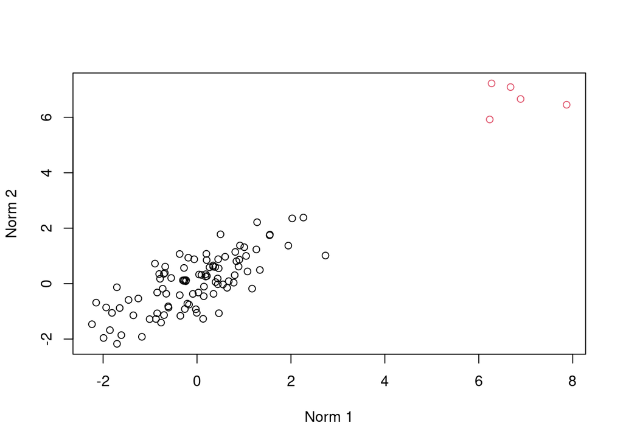

```r
class <- c(rep(1,n_good),rep(2,n_outliers))
plot(df_contaminated_normals,xlab="Norm 1", ylab="Norm 2",col=class)
```

We can clearly see those red points up there… how can we flag them in an automated fashion? The depth contour plot surely helps

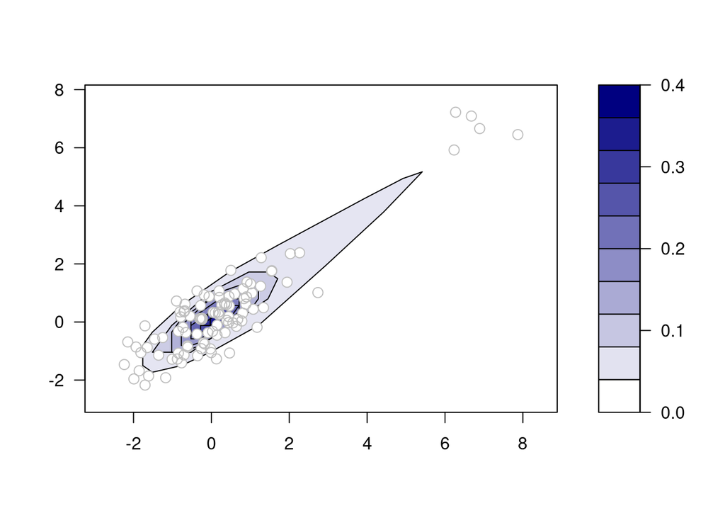

```r
depthContour(
  df_contaminated_normals,
  depth_params = list(method = 'Tukey'),
  points = TRUE,
  colors = colorRampPalette(c('white', 'navy')),
  levels = 10,
  pdmedian = F,
  graph_params = list(cex=.01, pch=1),
  pmean = F
)
```

But, as we have seen in class, a very handy graphical tool for spotting multivariate outliers is the bagplot. The `bagplot` function from the `aplpack` package can be used to display bagplots for bivariate data

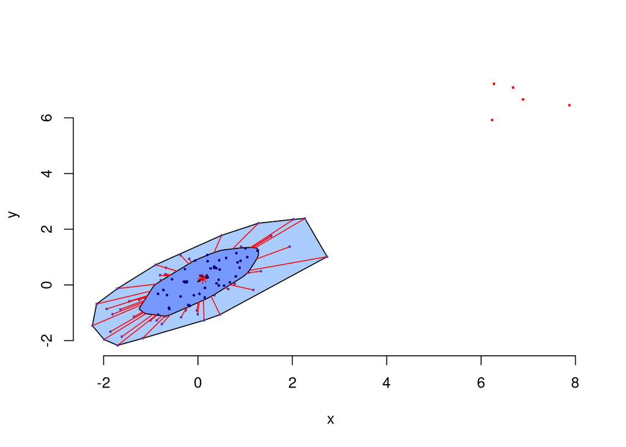

```r
bagplot(df_contaminated_normals, factor = 3, show.whiskers = T)
```

*Remember*:

- The *bag* is composed of the deepest 50% of the data (not to be confounded with the $.50$th central region $C_{.5}$, i.e. the smallest region enclosed by depth contours with at least probability $.50$: for that we would need to know the probability density function of the distribution the data came from!).
- The *fence* separates the outliers from the other observations
- The *loop* contains data between the bag and the fence
- Naturally, the median (i.e. the deepest datum) is inside the bag. If we check the help page for the `bagplot` function, we see that we have a lot of room for customization:

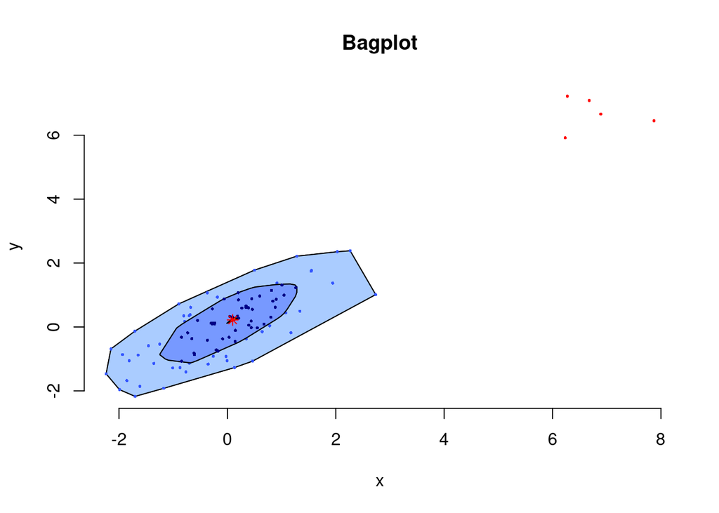

```r
aplpack::bagplot(df_contaminated_normals,show.whiskers = F,main="Bagplot")
```

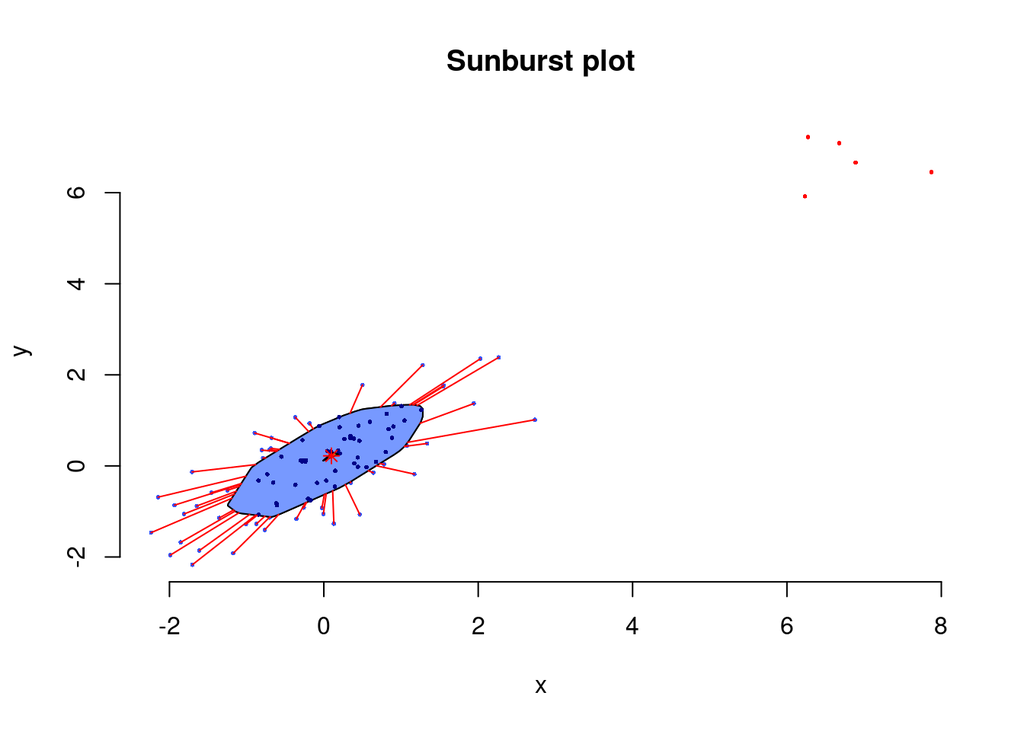

```r
aplpack::bagplot(df_contaminated_normals,show.loophull = F,main="Sunburst plot")
```

In addition, if we save the output of the bagplot to an object, we can automatically extract the outliers

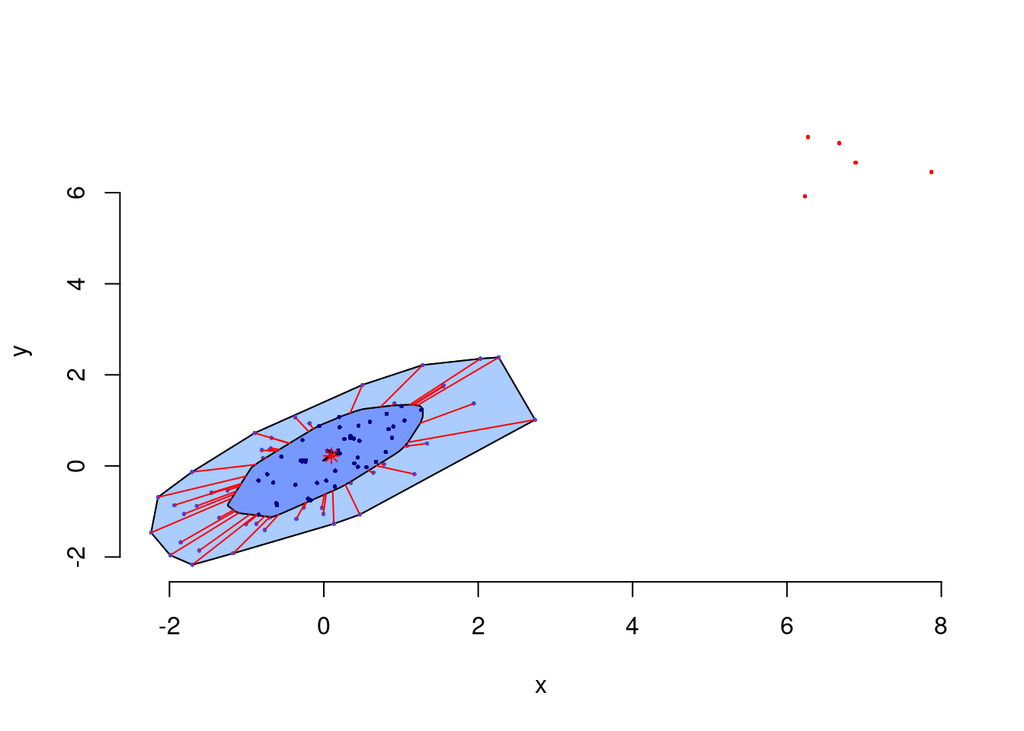

```r
bagplot_cont_normals <- bagplot(df_contaminated_normals)
```

```r
outlying_obs <- bagplot_cont_normals$pxy.outlier
```

Once the outlying units have been identified, one can discard them from the original data and keep working on the clean subset only. There are several ways to do this.

A more “sql-oriented” approach (this is just a code alternative):

```r
df_clean_1 <-
  dplyr::anti_join(
    x = df_contaminated_normals,
    y = outlying_obs,
    by = c("X1" = "x", "X2" = "y"),
    copy = TRUE
  )
```

A more “object-oriented programming” approach:

```r
ind_outlying_obs <- which(apply(df_contaminated_normals,1,function(x) all(x %in% outlying_obs)))
df_clean_2 <- df_contaminated_normals[-ind_outlying_obs,]
```

```r
all.equal(df_clean_1,df_clean_2)
```

```
## [1] TRUE
```

## Outlier detection in Star Cluster CYG OB1 data

Data for the Hertzsprung-Russell Diagram of the Star Cluster CYG OB1, which contains $47$ stars in the direction of Cygnus, from C.Doom.

- The first variable is the logarithm of the effective temperature at the surface of the star (Te)
- The second one is the logarithm of its light intensity (L/L0). The Hertzsprung-Russell diagram is the scatterplot of these data points, where the log temperature is plotted from left to right.

```r
data(starsCYG, package = "robustbase")
names(starsCYG)
```

```
## [1] "log.Te"    "log.light"
```

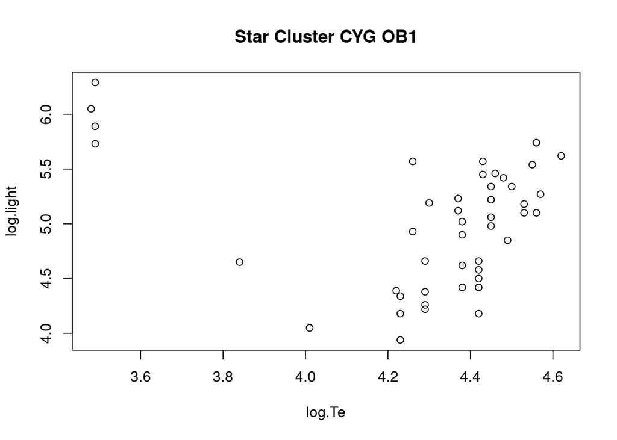

```r
plot(starsCYG, main="Star Cluster CYG OB1")
```

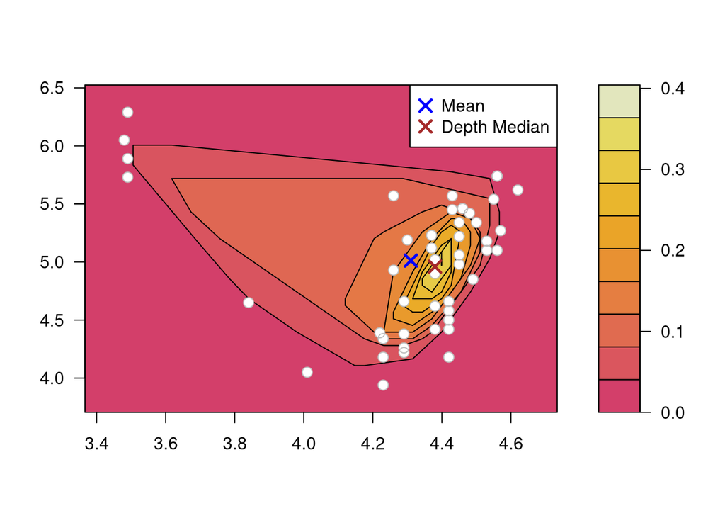

```r
depthContour(as.matrix(starsCYG), depth_params = list(method='Tukey'), points=TRUE)
```

As you can see, the sample mean is biased due to the presence of the 4 red giants, whereas the Tukey Median is not. Let us compute it:

```r
depthMedian(starsCYG)
```

```
##    log.Te log.light
##      4.38      5.02
```

As before, we can use the bagplot to visualize and flag the outlying data points.

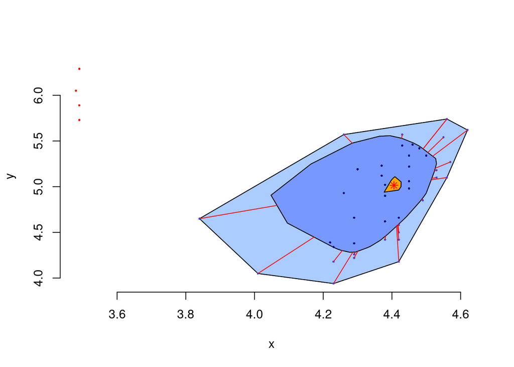

```r
bagplot_starsCYG <- with(starsCYG,aplpack::bagplot(log.Te,log.light))
```

```r
red_giants <- bagplot_starsCYG$pxy.outlier
ind_outlying_obs <- which(apply(starsCYG,1,function(x) all(x %in% red_giants)))
ind_outlying_obs
```

```
## [1] 11 20 30 34
```

## Moving beyond $R ^2$

So far, we have only dealt with bivariate data. Even though the computational complexity escalates quickly when it comes to compute depth measures in $R ^d$, with $d>2$, we can still appreciate their usefulness in moderate dimension. Let us generate a trivariate dataset with contamination.

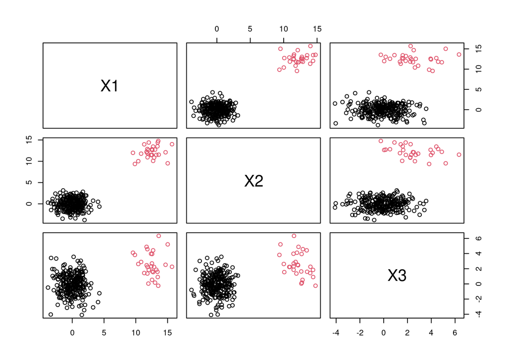

```r
mu_good = rep(0,3)
mu_outliers = c(12,12,3)

sigma_common = diag(3)*2

frac = .1
n=300
# sample points
n_good=ceiling(n*(1-frac))
n_outliers=n-n_good
df_3 = data.frame(rbind(
  mvrnorm(n_good, mu_good, sigma_common),
  mvrnorm(n_outliers, mu_outliers, sigma_common)
))
class <- c(rep(1,n_good),rep(2,n_outliers))
pairs(df_3, col=class)
```

To visualize the outliers in this context we retort to a bagplot matrix:

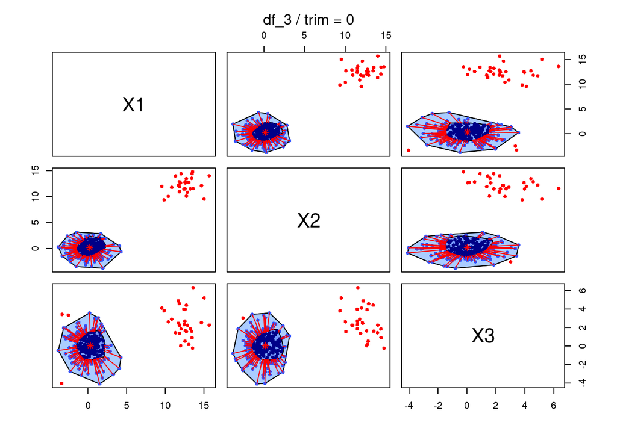

```r
bagplot_matrix <- aplpack::bagplot.pairs(df_3)
```

You can notice that outlier detection becomes more difficult when the dimension increases, as

- some outliers may be wrongly flagged as genuine points (**masking**)
- some good points may be wrongly flagged as outliers (**swamping**)

Let us conclude this lab session by looking at some DD-plots. For two probability distributions $F$ and $G$ , both in $R ^d$, and $D(\cdot)$ an affine-invariant depth, we can define depth vs. depth plot being very useful generalization of the one dimensional quantile-quantile plot:

$$D D(F, G)=\left\{\left(D_{F}(x), D_{G}(x)\right) \text { for all } x \in
\mathbb{R}^{d}\right\}$$

Its sample counterpart calculated for two samples $\mathbf{X} =\left\{X_1, \cdots, X_n \right\}$ from $F$, and $\mathbf{Y} =\left\{Y_1, \cdots, Y_m \right\}$ from $G$ is defined as

$$D D\left(F_{n}, G_{m}\right)=\left\{\left(D_{F_{n}}(z),
D_{G_{m}}(z)\right), z \in\{\mathbf{X} \cup \mathbf{Y}\}\right\}$$

The `ddPlot` function automatically computes and plots it:

```
## DDPlot
```

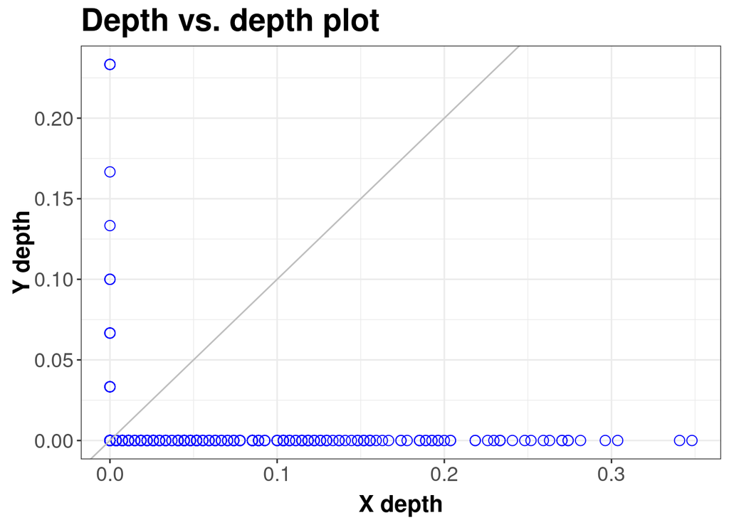

```
##
## Depth Metohod:
##   Tukey
```

```r
df_good <- df_3[1:n_good,]
df_out <- df_3[(n_good+1):n,]
ddPlot(x = df_good,y = df_out,depth_params = list(method='Tukey'))
```

They would line up if they came from the same distribution

It is easy to manually build a DD-plot

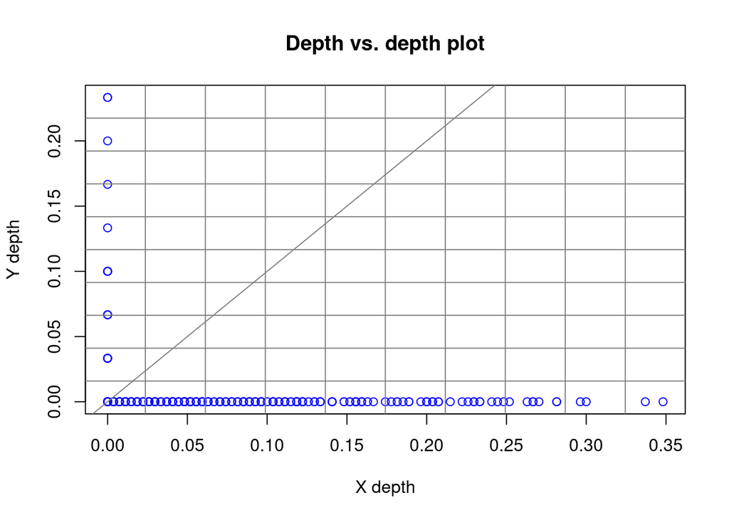

```r
depth_good <- depth(u = df_3,X = df_good,method = "Tukey")
depth_out <- depth(u = df_3,X = df_out,method = "Tukey")
plot(depth_good,depth_out, col="blue", xlab="X depth", ylab="Y depth", main= "Depth vs. depth plot")
grid(10, 10, col="grey50", lty=1)
abline(0,1, col="grey50")
```

Clearly the distributions are not the same… What if we had some extra samples coming from $F$ (e.g., the trivariate normal centered at $0$)?

```
## DDPlot
```

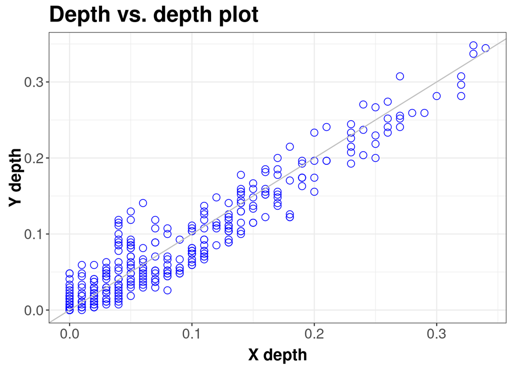

```
##
## Depth Metohod:
##   Tukey
```

```r
n_extra <- 100
df_extra <- data.frame(mvrnorm(n_extra, mu_good, sigma_common))
ddPlot(x = df_extra, df_good,depth_params=list(method='Tukey'))
```

Indeed this time we can conclude the same distribution generated the data.

## Measuring robustness.

### *Breakdown point*

The *breakdown point* measures the minimum data corruption required to bring estimates very far away from the correct values.

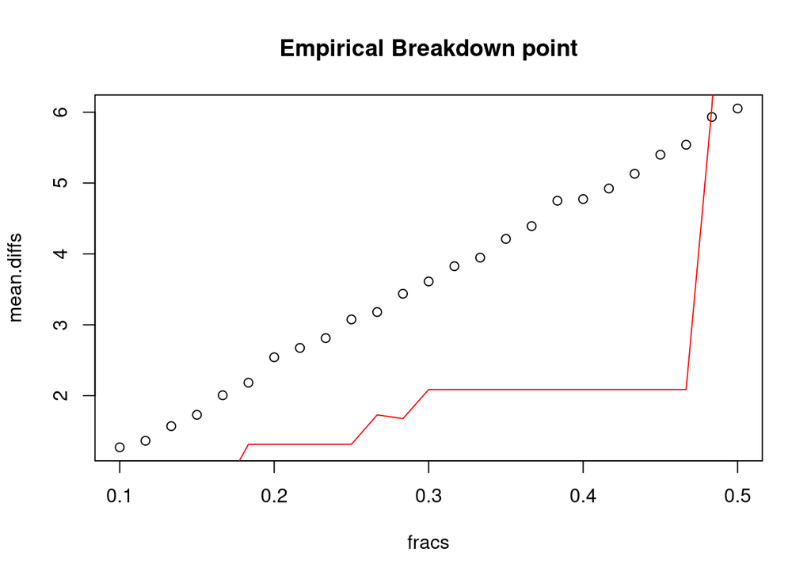

```r
fracs <- seq(0.1, .5, length.out=25)  # vector of contamination percentages
set.seed(41703192)
n_good <- 100
df.clean <- data.frame(mvrnorm(n_good, mu_good, sigma_common))
multivar.mean.clean <- colMeans(df.clean)
multivar.median.clean <- depthMedian(df.clean,depth_params = list(method='Tukey'))

mean.diffs <- numeric(length(fracs))
median.diffs <- numeric(length(fracs))

for (i in 1:length(fracs)){  # iterate across different values of contamination
  n=100
  # sample points
  frac <- fracs[i]
  n_good=ceiling(n*(1-frac))
  n_outliers=n-n_good

  df_contaminated_normals = data.frame(rbind(
  as.matrix(df.clean[1:n_good, ]),
  mvrnorm(n_outliers, mu_outliers, sigma_common)
  ))
  current.mean <- colMeans(df_contaminated_normals)
  current.median <- depthMedian(df_contaminated_normals, depth_params = list(method='Tukey'))

  mean.diffs[i] <- max(abs(current.mean - multivar.mean.clean) )
  median.diffs[i] <- max(abs(current.median - multivar.median.clean))
}

plot(x=fracs, y=mean.diffs, main="Empirical Breakdown point")
lines(x=fracs, y=median.diffs, col="red")
```

### Empirical Influence function

Now we calculate (empirically) the measure of dependence of the estimator on the value of one of the points in the sample.

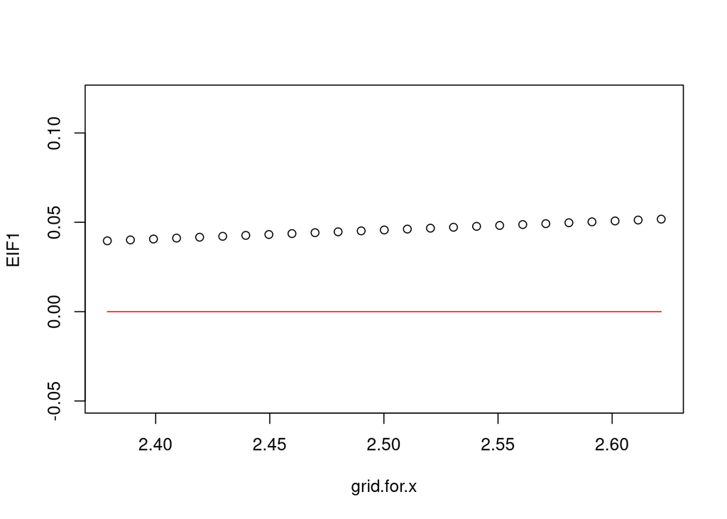

```r
sim.data <- rnorm(20) # univariate standard normal distribution sample
stat1 <- function(data){base::mean(data)}
stat2 <- function(data){median(data)}

L = 25
grid.for.x <- seq(-1.5*min(sim.data), max(sim.data)*1.5, length.out=L)

stat1.0 <- base::mean(sim.data)
stat2.0 <- stat2(sim.data)

EIF1 <- numeric(L)
EIF2 <- numeric(L)
for (i in 1:length(grid.for.x)){   # iterate across different values
  sim.data.i <- sim.data
  sim.data.i[1] <- grid.for.x[i] # change the first value in the sample
  EIF1[i] <- abs(base::mean(sim.data.i) - stat1.0)
  EIF2[i] <- abs(stat2(sim.data.i) - stat2.0)
}

plot(x=grid.for.x, y=EIF1, ylim=c(-.05, .12))
lines(x=grid.for.x, y=EIF2, col="red")
```

### Empirical influence value

An alternative is the **empirical influence value**: the (estimated) the derivative of a sample estimator with respect to each statistical unit in the sample of its input. One must be careful on the definition of the statistic. It is implemented in the `boot` package and the statistic (i.e. a functional of the sample), has to be an (R) function of the data matrix and **a vector of weights**, i.e the weight associated to each statistical unit (row in the matrix), see more information [here](https://stat.ethz.ch/R-manual/R-devel/library/boot/html/empinf.html)